# LBB Neural Network

Francis Yeh

22 Apr 2020

# 1 Introduction

## 1.1 Background

Under the fmnist folder in data_input directory, the folder contains train and test set of 10 different categories for 28 x 28 pixel sized fashion images, use the following glossary for your target labels:

categories <- c(“T-shirt”, “Trouser”, “Pullover”, “Dress”, “Coat”, “Sandal”, “Shirt”, “Sneaker”, “Bag”, “Boot”)

Tasks to be performed

Data preparation.

Design neural network layer design for input, hidden, output layer, and activation functions.

Demonstrate cross validation method and model evaluation.

## 1.2 Data Source

Dataset of 60,000 28x28 grayscale images of 10 fashion(clothes) categories, along with a test set of 10,000 images. You can learn more on Wikipedia:

https://en.wikipedia.org/wiki/MNIST_database

### 1.2.1 Overview of Label

Label Description

0 T-shirt/top

1 Trouser

2 Pullover

3 Dress

4 Coat

5 Sandal

6 Shirt

7 Sneaker

8 Bag

9 Ankle boot

## 1.3 Libraries and Setup

```r
knitr::opts_chunk$set(cache=TRUE)
options(scipen = 9999)
```

To run the data preparation and the statistical analysis, the following libraries are loaded

```r
#suppressMessages(library(Hmisc))
suppressMessages(library(keras))
suppressMessages(library(caret))
suppressMessages(library(data.table))
```

## 1.4 References

[1]: [Keras Sequential Model Guide](https://keras.io/getting-started/sequential-model-guide/)

[2]: [Convolutional Networks by Stanford University](https://cs231n.github.io/convolutional-networks/)

# 2 Preprocessing

## 2.1 Data Table

```r
library(data.table)
fmnist_train <- fread("data_input/fmnist/train.csv")
fmnist_test <- fread("data_input/fmnist/test.csv")
```

## 2.2 Transform Train/Test data into a matrix

```r
# Turn the data frames into matrices
ftrain <- data.matrix(fmnist_train)
ftest <- data.matrix(fmnist_test)

# Strip the dimnames of ntrain and ntest.
dimnames(ftrain) <- NULL
dimnames(ftest) <- NULL
```

## 2.3 Setting up Train/Test Data and Labels

```r
# Separate the labels from the train sets.
ftrain_data <- ftrain[, -1]
ftrain_label <- ftrain[, 1]

# This time we do it for the test set as well
ftest_data <- ftest[, -1]
ftest_label <- ftest[, 1]



# Use One-hot-encoding on the labels via the to_categorical() function.
ftrain_label_hot <- to_categorical(ftrain_label, 10)
ftest_label_hot <- to_categorical(ftest_label, 10)
```

## 2.4 Rescale all data

```r
# Rescale all data from 0:255 into 0:1
ftrain_data <- ftrain_data/255
ftest_data <- ftest_data/255
```

## 2.5 Functions to enable the display of images

### 2.5.1 Function to plot results

```r
# The "plotResults" function will print the image, but this time it will display the predicted result on the left of the image in white.
# This is just a tool to help us check if our prediction was accurate.
plotResults <- function(images, preds) {

    x <- ceiling(sqrt(length(images)))
    par(mfrow = c(x, x), mar = c(0.1, 0.1, 0.1, 0.1))

    for (i in images) {
        m <- matrix(ftest_data[i, ], nrow = 28, byrow = TRUE)
        m <- apply(m, 2, rev)
        image(t(m), col = grey.colors(255), axes = FALSE)
        text(0.05, 0.1, col = "white", cex = 1.2, preds[i])
    }

}
```

# 3 Neural Network Model - Initial

## 3.1 Step 1: Define the model

```r
# apply layers using layer_dense()
modelf <- keras_model_sequential() %>%
  layer_dense(units = 128, activation = "relu", input_shape = c(784)) %>%
  layer_dense(units = 64, activation = "relu") %>%
  layer_dense(units = 10, activation = "softmax")

summary(modelf)
```

```
## Model: "sequential"
## ________________________________________________________________________________
## Layer (type)                        Output Shape                    Param #
## ================================================================================
## dense (Dense)                       (None, 128)                     100480
## ________________________________________________________________________________
## dense_1 (Dense)                     (None, 64)                      8256
## ________________________________________________________________________________
## dense_2 (Dense)                     (None, 10)                      650
## ================================================================================
## Total params: 109,386
## Trainable params: 109,386
## Non-trainable params: 0
## ________________________________________________________________________________
```

## 3.2 Step 2: Compile the model

```r
modelf %>%
  compile(loss = "categorical_crossentropy",
          optimizer = "adam",
          metrics = "accuracy")
```

## 3.3 Step 3: Train the model

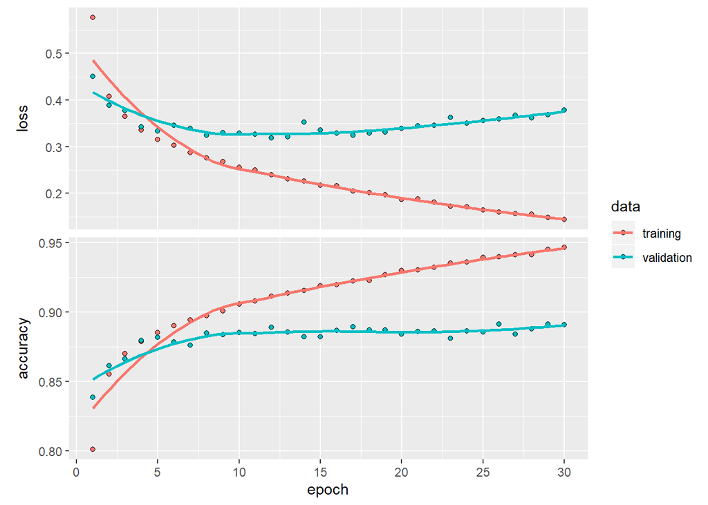

```r
historyf <- modelf %>%
  fit(x = ftrain_data,
      y = ftrain_label_hot,
      epoch = 30,
      batch_size = 128,
      validation_split = 0.2)


plot(historyf)
```

### 3.3.1 Predict the results when the test set is passed into our trained Neural Network

```r
# Predict the results when the test set is passed into our trained NN.
prediction_test <- predict_classes(object = modelf, x =  ftest_data)

# Print the first 10 prediction results.
prediction_test[1:10]
```

```
##  [1] 0 1 2 6 4 6 8 3 5 0
```

### 3.3.2 Display the test images after Prediction

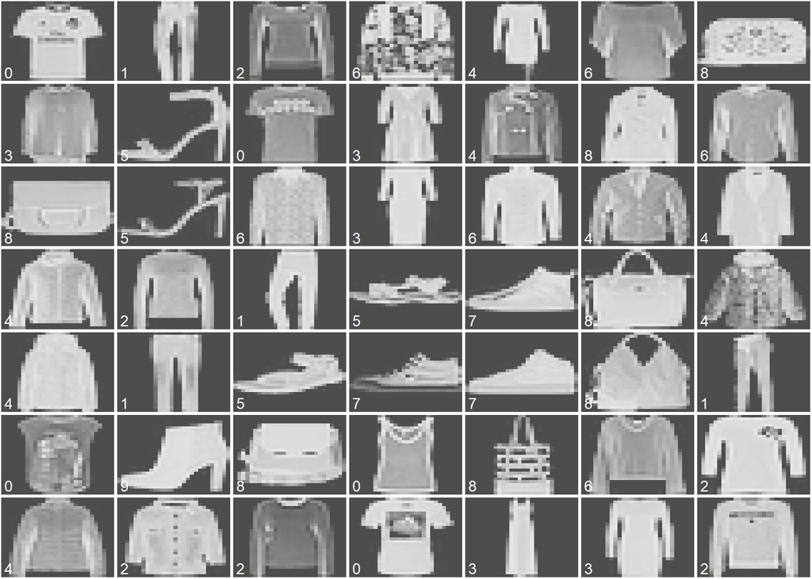

```r
# Use plotResults function that we created above to display the first 50 fashion images as well as our predicted result for that image.
plotResults(1:49, prediction_test)
```

### 3.3.3 Display the Metrices

```r
historyf$metrics$acc
```

```
##  [1] 0.8010833 0.8553542 0.8701459 0.8785833 0.8852500 0.8900833 0.8943750
##  [8] 0.8972292 0.9006667 0.9055833 0.9078541 0.9113542 0.9134791 0.9156042
## [15] 0.9189792 0.9194583 0.9221458 0.9228542 0.9269167 0.9299583 0.9300625
## [22] 0.9322500 0.9352500 0.9358541 0.9392083 0.9396458 0.9410625 0.9410625
## [29] 0.9448541 0.9464167
```

## 3.4 Step 4: Evaluate the model

```r
evaf <- modelf %>%
  evaluate(ftest_data, ftest_label_hot)

# Save all the probabilities of the prediction produced at the output layer into probf.
probf <- modelf %>%
  predict_proba(ftest_data)

# Save all the predicted classes into predf.
predf <- modelf %>%
  predict_classes(ftest_data)
```

```r
categories <- c("T-shirt", "Trouser", "Pullover", "Dress", "Coat", "Sandal", "Shirt", "Sneaker", "Bag", "Boot")
predf <- factor(predf, labels=categories)
finaltest_label <- ftest_label
ftest_label <- factor(ftest_label, labels=categories)
```

```r
cat('Test loss:', evaf[[1]], '\n')
```

```
## Test loss: 0.345571
```

```r
cat('Test accuracy:', evaf[[2]], '\n')
```

```
## Test accuracy: 0.8962
```

### 3.4.1 Confusion Matrix

```r
# Create a simple confusion matrix using the table() function.
table(Predicted = predf, Actual = ftest_label)
```

```
##           Actual
## Predicted  T-shirt Trouser Pullover Dress Coat Sandal Shirt Sneaker Bag Boot
##   T-shirt      852       3       12    15    2      3   125       0   3    1
##   Trouser        0     985        1     9    1      1     2       0   0    0
##   Pullover      15       2      828     5   71      0    64       0   6    0
##   Dress         30       8       20   929   31      1    42       0   1    0
##   Coat           2       1       65    27  846      0    56       0   2    0
##   Sandal         2       0        0     0    0    949     0      22   6    5
##   Shirt         89       0       65     9   45      0   697       0   4    0
##   Sneaker        0       0        0     0    0     27     0     930   1   24
##   Bag           10       1        9     6    4      2    13       0 977    1
##   Boot           0       0        0     0    0     17     1      48   0  969
```

```r
# Use the confusionMatrix() function from library(caret) that generates the accuracies and other useful info.
caret::confusionMatrix(table(Predicted = predf, Actual = ftest_label))
```

```
## Confusion Matrix and Statistics
##
##           Actual
## Predicted  T-shirt Trouser Pullover Dress Coat Sandal Shirt Sneaker Bag Boot
##   T-shirt      852       3       12    15    2      3   125       0   3    1
##   Trouser        0     985        1     9    1      1     2       0   0    0
##   Pullover      15       2      828     5   71      0    64       0   6    0
##   Dress         30       8       20   929   31      1    42       0   1    0
##   Coat           2       1       65    27  846      0    56       0   2    0
##   Sandal         2       0        0     0    0    949     0      22   6    5
##   Shirt         89       0       65     9   45      0   697       0   4    0
##   Sneaker        0       0        0     0    0     27     0     930   1   24
##   Bag           10       1        9     6    4      2    13       0 977    1
##   Boot           0       0        0     0    0     17     1      48   0  969
##
## Overall Statistics
##
##                Accuracy : 0.8962
##                  95% CI : (0.8901, 0.9021)
##     No Information Rate : 0.1
##     P-Value [Acc > NIR] : < 0.00000000000000022
##
##                   Kappa : 0.8847
##
##  Mcnemar's Test P-Value : NA
##
## Statistics by Class:
##
##                      Class: T-shirt Class: Trouser Class: Pullover Class: Dress
## Sensitivity                  0.8520         0.9850          0.8280       0.9290
## Specificity                  0.9818         0.9984          0.9819       0.9852
## Pos Pred Value               0.8386         0.9860          0.8355       0.8748
## Neg Pred Value               0.9835         0.9983          0.9809       0.9921
## Prevalence                   0.1000         0.1000          0.1000       0.1000
## Detection Rate               0.0852         0.0985          0.0828       0.0929
## Detection Prevalence         0.1016         0.0999          0.0991       0.1062
## Balanced Accuracy            0.9169         0.9917          0.9049       0.9571
##                      Class: Coat Class: Sandal Class: Shirt Class: Sneaker
## Sensitivity               0.8460        0.9490       0.6970         0.9300
## Specificity               0.9830        0.9961       0.9764         0.9942
## Pos Pred Value            0.8468        0.9644       0.7668         0.9470
## Neg Pred Value            0.9829        0.9943       0.9667         0.9922
## Prevalence                0.1000        0.1000       0.1000         0.1000
## Detection Rate            0.0846        0.0949       0.0697         0.0930
## Detection Prevalence      0.0999        0.0984       0.0909         0.0982
## Balanced Accuracy         0.9145        0.9726       0.8367         0.9621
##                      Class: Bag Class: Boot
## Sensitivity              0.9770      0.9690
## Specificity              0.9949      0.9927
## Pos Pred Value           0.9550      0.9362
## Neg Pred Value           0.9974      0.9965
## Prevalence               0.1000      0.1000
## Detection Rate           0.0977      0.0969
## Detection Prevalence     0.1023      0.1035
## Balanced Accuracy        0.9859      0.9808
```

# 4 Neural Network Model - Final

## 4.1 Step 1: Define the model

```r
library(keras)
input_shape <- c(28,28,1)
modelfinal <- keras_model_sequential()
modelfinal %>%
  layer_conv_2d(filters = 32, kernel_size = c(5,5), activation = 'relu',
                input_shape = input_shape) %>%
  layer_conv_2d(filters = 64, kernel_size = c(3,3), activation = 'relu') %>%
  layer_max_pooling_2d(pool_size = c(2, 2)) %>%
  layer_dropout(rate = 0.25) %>%
  layer_flatten() %>%
  layer_dense(units = 128, activation = 'relu') %>%
  layer_dropout(rate = 0.5) %>%
  layer_dense(units = 10, activation = 'softmax')
```

## 4.2 Step 2: Compile the model

```r
modelfinal %>% compile(
  loss = loss_categorical_crossentropy,     # https://keras.io/optimizers/
  optimizer = optimizer_adam(),    # https://arxiv.org/pdf/1212.5701.pdf
  metrics = c('accuracy')
)
```

## 4.3 Step 3: Train the model

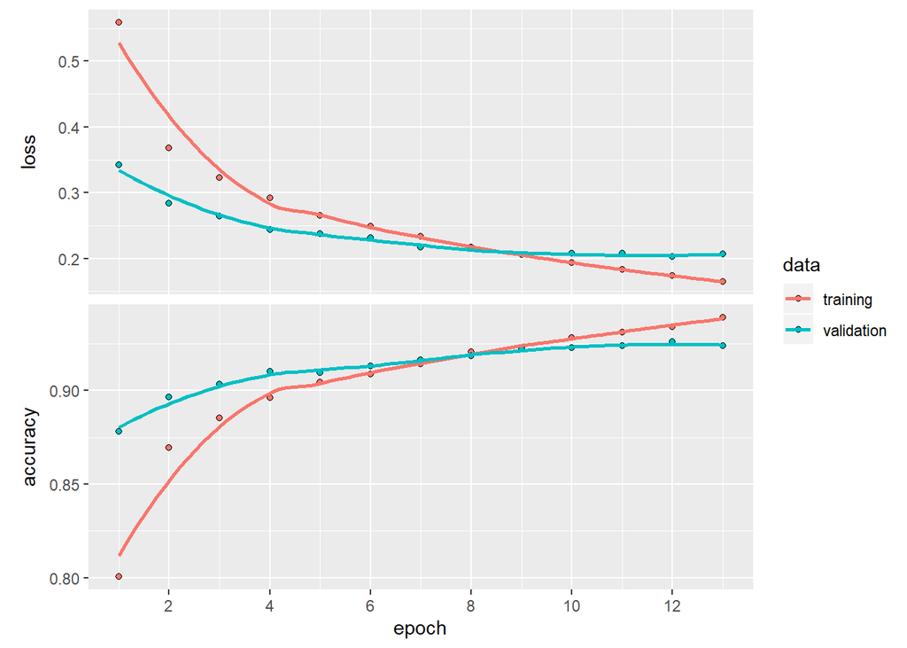

```r
dim(ftrain_data) <- c(nrow(ftrain_data), 28, 28, 1)
dim(ftest_data) <- c(nrow(ftest_data), 28, 28, 1)

historyfinal <- modelfinal %>%
  fit(x = ftrain_data,
      y = ftrain_label_hot,
      epoch = 13,
      batch_size = 128,
      validation_data = list(ftest_data, ftest_label_hot))

plot(historyfinal)
```

## 4.4 Step 4: Evaluate the model

```r
evafinal <- modelfinal %>%
  evaluate(ftest_data, ftest_label_hot)

# Save all the probabilities of the prediction produced at the output layer into probfinal.
probfinal <- modelfinal %>%
  predict_proba(ftest_data)

# Save all the predicted classes into predfinal.
predfinal <- modelfinal %>%
  predict_classes(ftest_data)
```

```r
# Predict the results when the test set is passed into our trained NN.
prediction_test_final <- predict_classes(object = modelfinal, x =  ftest_data)

# Print the first 10 prediction results.
prediction_test_final[1:10]
```

```
##  [1] 0 1 2 6 3 6 8 6 5 0
```

```r
#categories <- c("T-shirt", "Trouser", "Pullover", "Dress", "Coat", "Sandal", "Shirt", "Sneaker", "Bag", "Boot")
predfinal <- factor(predfinal, labels=categories)
finaltest_label <- factor(finaltest_label, labels=categories)
```

```r
cat('Test loss:', evafinal[[1]], '\n')
```

```
## Test loss: 0.2071187
```

```r
cat('Test accuracy:', evafinal[[2]], '\n')
```

```
## Test accuracy: 0.9239
```

### 4.4.1 Confusion Matrix

```r
# Create a simple confusion matrix using the table() function.
table(Predicted = predfinal, Actual = finaltest_label)
```

```
##           Actual
## Predicted  T-shirt Trouser Pullover Dress Coat Sandal Shirt Sneaker Bag Boot
##   T-shirt      887       2       10    18    0      0   125       0   2    0
##   Trouser        0     983        0     4    1      0     0       0   1    0
##   Pullover      20       1      891     5   48      0    54       0   0    0
##   Dress         10       9       10   947   23      0    27       0   0    0
##   Coat           0       0       42    14  880      0    51       0   2    0
##   Sandal         0       0        0     0    0    980     0       3   0    2
##   Shirt         73       3       46    12   45      0   738       0   4    0
##   Sneaker        0       0        0     0    0     11     0     964   1   19
##   Bag           10       2        1     0    3      1     5       0 990    0
##   Boot           0       0        0     0    0      8     0      33   0  979
```

```r
# Use the confusionMatrix() function from library(caret) that generates the accuracies and other useful info.
caret::confusionMatrix(table(Predicted = predfinal, Actual = finaltest_label))
```

```
## Confusion Matrix and Statistics
##
##           Actual
## Predicted  T-shirt Trouser Pullover Dress Coat Sandal Shirt Sneaker Bag Boot
##   T-shirt      887       2       10    18    0      0   125       0   2    0
##   Trouser        0     983        0     4    1      0     0       0   1    0
##   Pullover      20       1      891     5   48      0    54       0   0    0
##   Dress         10       9       10   947   23      0    27       0   0    0
##   Coat           0       0       42    14  880      0    51       0   2    0
##   Sandal         0       0        0     0    0    980     0       3   0    2
##   Shirt         73       3       46    12   45      0   738       0   4    0
##   Sneaker        0       0        0     0    0     11     0     964   1   19
##   Bag           10       2        1     0    3      1     5       0 990    0
##   Boot           0       0        0     0    0      8     0      33   0  979
##
## Overall Statistics
##
##                Accuracy : 0.9239
##                  95% CI : (0.9185, 0.929)
##     No Information Rate : 0.1
##     P-Value [Acc > NIR] : < 0.00000000000000022
##
##                   Kappa : 0.9154
##
##  Mcnemar's Test P-Value : NA
##
## Statistics by Class:
##
##                      Class: T-shirt Class: Trouser Class: Pullover Class: Dress
## Sensitivity                  0.8870         0.9830          0.8910       0.9470
## Specificity                  0.9826         0.9993          0.9858       0.9912
## Pos Pred Value               0.8496         0.9939          0.8744       0.9230
## Neg Pred Value               0.9874         0.9981          0.9879       0.9941
## Prevalence                   0.1000         0.1000          0.1000       0.1000
## Detection Rate               0.0887         0.0983          0.0891       0.0947
## Detection Prevalence         0.1044         0.0989          0.1019       0.1026
## Balanced Accuracy            0.9348         0.9912          0.9384       0.9691
##                      Class: Coat Class: Sandal Class: Shirt Class: Sneaker
## Sensitivity               0.8800        0.9800       0.7380         0.9640
## Specificity               0.9879        0.9994       0.9797         0.9966
## Pos Pred Value            0.8898        0.9949       0.8013         0.9688
## Neg Pred Value            0.9867        0.9978       0.9711         0.9960
## Prevalence                0.1000        0.1000       0.1000         0.1000
## Detection Rate            0.0880        0.0980       0.0738         0.0964
## Detection Prevalence      0.0989        0.0985       0.0921         0.0995
## Balanced Accuracy         0.9339        0.9897       0.8588         0.9803
##                      Class: Bag Class: Boot
## Sensitivity              0.9900      0.9790
## Specificity              0.9976      0.9954
## Pos Pred Value           0.9783      0.9598
## Neg Pred Value           0.9989      0.9977
## Prevalence               0.1000      0.1000
## Detection Rate           0.0990      0.0979
## Detection Prevalence     0.1012      0.1020
## Balanced Accuracy        0.9938      0.9872
```

# 5 Summary

In the second Neural Network model, we look into tuning the dropout rate for regularization in an effort to limit overfitting and improve the model’s ability to generalize. To improve the performance, we also reduce the number of epochs from 30 to 13 and implement convolution and pooling layers into the model[^1].

Overall, the accuracy (0.9239) and loss (0.207) for the Test of 2nd Neural Network Model is better than accuracy(0.8962) and loss(0.3455) of the first Neural Network Model. The overall performance for Sensitivity, Specificity, Pos Pred Value and Neg Pred Value for the second NN model is generally higher than the first NN model .